# Comparion JupyFluo and PyMca

```python
%%latex
\tableofcontents
\newpage
```

```python
# RUN THIS CELL TO START

__version__ = '0.6.1'
print("JupyFluo version: %s"%__version__)
print("More info on: %s"%"https://gitlab.com/soleil-data-treatment/soleil-beamlines/soleil-beamline-sirius/JupyFluo")

import matplotlib.pyplot as plt
%matplotlib inline
import numpy as np

# import custom libraries
from lib.frontend.experiment import Experiment
from lib.frontend.myWidgets import myWidgets
from lib.extraction import PyNexus as PN
import lib.frontend.main as FE

# To get vector plots in the PDF
import matplotlib_inline.backend_inline
matplotlib_inline.backend_inline.set_matplotlib_formats('png', 'pdf')

# Expand the result cells
from IPython.display import Javascript, display
display(Javascript('IPython.OutputArea.prototype._should_scroll = function(lines) {return false;}'))

# Name of the notebook (necessary for saving in pdf)
notebook_name = 'comparison_jupyfluo_pymca.ipynb'

# Directory where the data will be saved
save_dir = "save/"

# Directory where the nexus files are
files_dir = "../files/"

# Logs depth level (default = 0, extensive = 1)
logs_lvl = 0

# Create the objects Experiment and myWidgets
expt = Experiment(notebook_name, save_dir, files_dir, logs_lvl)
wid = myWidgets()

# Check the files and create the interactive cell
expt.check_and_init()
```

```
JupyFluo version: 0.6.1
More info on: https://gitlab.com/soleil-data-treatment/soleil-beamlines/soleil-beamline-sirius/JupyFluo
```

```
Results will be saved in the directory:
save/
Scans (nexus files) should be in the directory:
../files/
```

# SIRIUS_Fluo_2020_02_16_02289

## Fit with JupyFluo

### Session ID: 20220207_203848

Fit results for file `SIRIUS_Fluo_2020_02_16_02289.nxs`  
Parameters and results saved in:  
`save/SIRIUS_Fluo_2020_02_16_02289/20220207_203848/`

**Extraction parameters**  
Spectrum interval = [0, 1405]  
Channel interval = [140, 1250]  
SDD elements used = [4]

**Fit parameters**  
List of fitted parameters: ['sl', 'ct']  
beam energy = 12000; min. strength = 0.01  
**Params for conversion to eVs**  
gain = 9.9279; eV0 = -18.4341  
**Params for linear background**  
slope = 0.001; constant = 2.163  
Fit the background on the subset [4000 eV, 6000 eV]  
**Params for elastic peaks**  
noise = 0.1051; tail fraction (low energy side) = 0  
tail width (low energy side) = 0; shelf fraction = 0.6993  
**Params for Compton peaks**  
broadening factor = 1; tail fraction (low energy side) = 0.1089; tail fraction (high energy side) = 0  
tail width (low energy side) = 5; tail width (high energy side) = 0

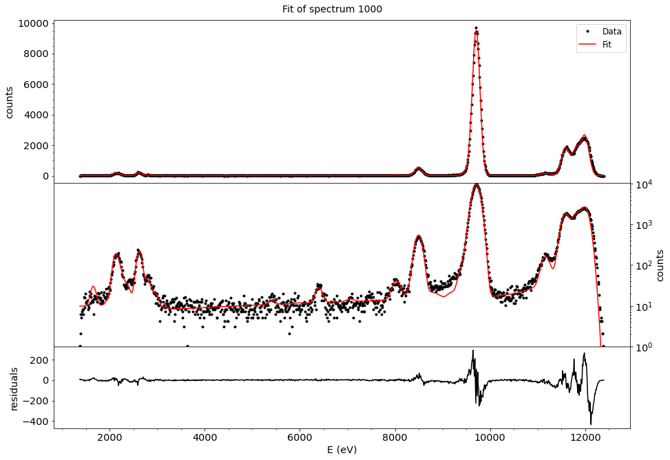

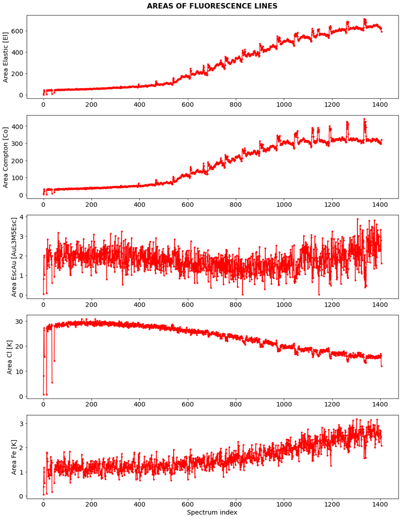

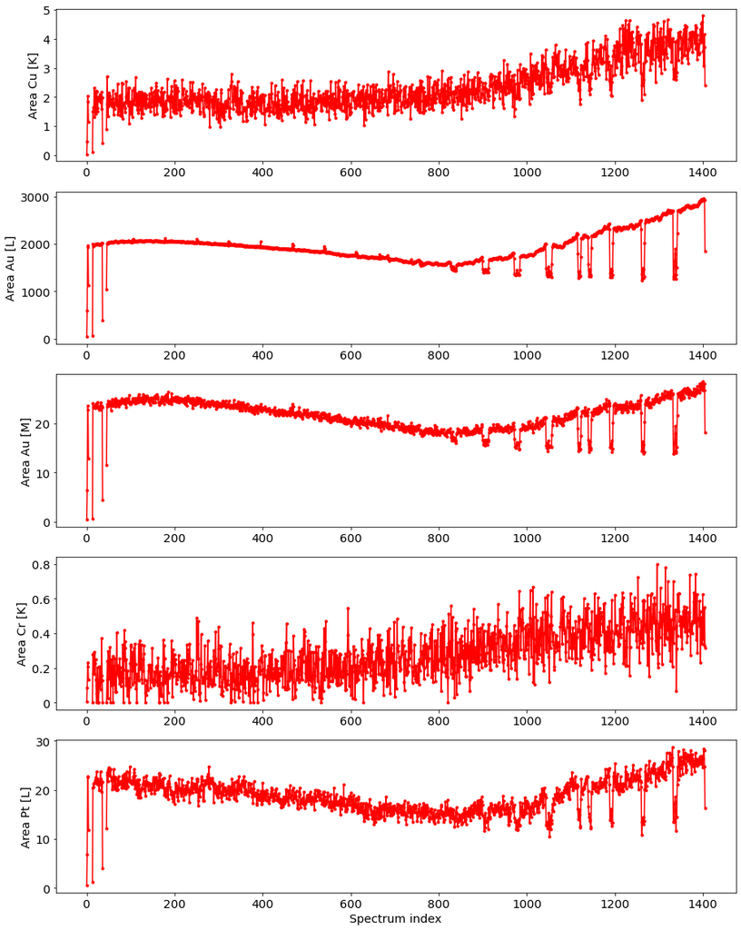

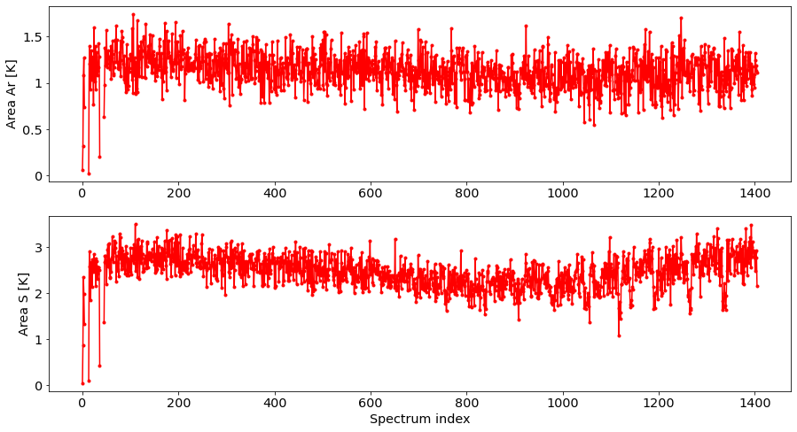

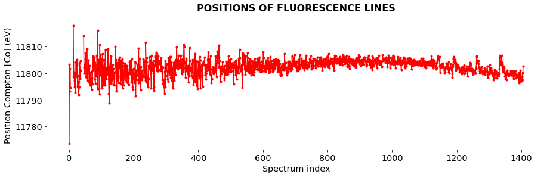

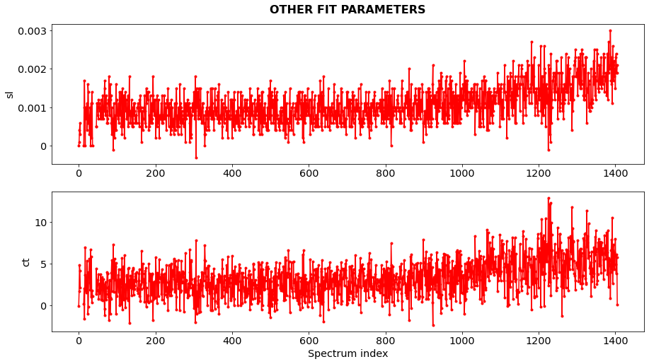

```python
fit_index=1000
path_to_result_folder='save/SIRIUS_Fluo_2020_02_16_02289/20220207_203848/'
expt.plot_all_fit_results(fit_index, path_to_result_folder)
```

## Comparison with PyMca

### Curves

```python
file_curve_pymca = '../2289/Results_batch/FIT/SIRIUS_Fluo_2020_02_16_02289.nxs_FITDIR/SIRIUS_Fluo_2020_02_16_02289.nxs_1.0000.1000.fit'
with open(file_curve_pymca) as a_file:
    for line in a_file:
        if 'energy = [' in line:
            energy_pymca = [float(x)*1000. for x in line.split('energy = ')[1][2:-3].split(' ')]
        if 'ydata = [' in line:
            ydata_pymca = [float(x) for x in line.split('ydata = ')[1][2:-3].split(' ')]
        if 'yfit = [' in line:
            yfit_pymca = [float(x) for x in line.split('yfit = ')[1][2:-3].split(' ')]


file_curve_jupy = 'save/SIRIUS_Fluo_2020_02_16_02289/20220207_203848/fit_curves/spectrum_1000.csv'
curve_jupy = np.genfromtxt(file_curve_jupy, delimiter =';', names = True)

energy_jupy = curve_jupy['eVs']
ydata_jupy = curve_jupy['data']
yfit_jupy = curve_jupy['fit']
```

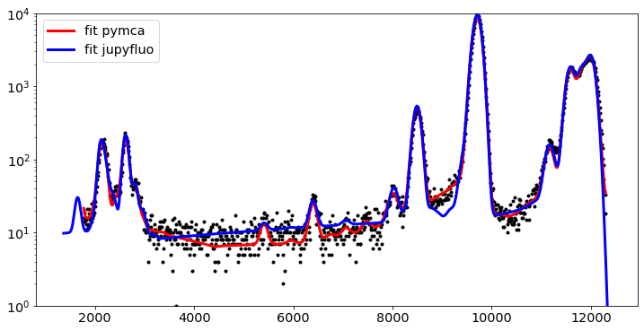

```python
fig = plt.figure(figsize=(12,6))
plt.plot(energy_pymca, ydata_pymca, 'k.')
plt.plot(energy_pymca, yfit_pymca, 'r-', lw = 3, label = 'fit pymca')
plt.plot(energy_jupy, yfit_jupy, 'b-', lw = 3, label = 'fit jupyfluo')

#plt.plot(x, y_jupy*ratio, label = 'jupyfluo')
plt.yscale('log')
plt.ylim(1,1e4)
plt.legend()
plt.show()
```

### Fit results

```python
data_pymca = np.genfromtxt('../2289/Results_batch/IMAGES/SIRIUS_Fluo_2020_02_16_02289.csv',
                     delimiter =';', names = True)[0:1406]
print('header pymca:\n',data_pymca.dtype.names)
data_jupy = np.genfromtxt('save/SIRIUS_Fluo_2020_02_16_02289/20220207_203848/fit_results.csv',
                           delimiter =';', names = True)
print('')
print('header jupyfluo:\n',data_jupy.dtype.names)
```

```
header pymca:
 ('row', 'column', 'S_Kb', 'Cl_Ka', 'Cl_Kb', 'Ar_K', 'Cr_K', 'Fe_K', 'Ni_K', 'Cu_K', 'Au_L', 'Au_M', 'Scatter_Peak000', 'Scatter_Compton000', 'sS_Kb', 'sCl_Ka', 'sCl_Kb', 'sAr_K', 'sCr_K', 'sFe_K', 'sNi_K', 'sCu_K', 'sAu_L', 'sAu_M', 'sScatter_Peak000', 'sScatter_Compton000', 'chisq')

header jupyfluo:
 ('ys', 'zs', 'xs', 'surfacepressure', 'areapermolecule', 'area', 'fluo01', 'fluo02', 'fluo03', 'fluo04', 'fluoicr04', 'fluoocr04', 'integration_time', 'sensorsRelTimestamps', 'sensorsTimestamps', 'spectrum_index', 'area_Elastic_El', 'stderr_area_Elastic_El', 'area_Compton_Co', 'stderr_area_Compton_…
```

#### Area Au

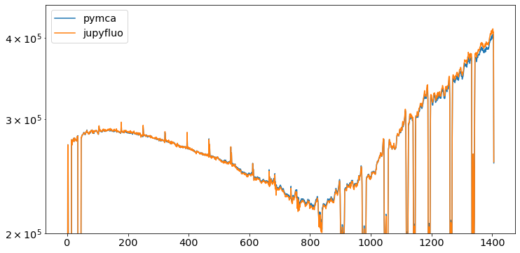

```python
x = data_pymca['column']
y_pymca = data_pymca['Au_L']
y_jupy = data_jupy['area_Au_L']

# Average ratio to scale the two curves
ratio = np.nanmean(y_pymca/y_jupy)

fig = plt.figure(figsize=(12,6))
plt.plot(x, y_pymca, label = 'pymca')
plt.plot(x, y_jupy*ratio, label = 'jupyfluo')
plt.yscale('log')
plt.ylim(2e5,4.5e5)
plt.legend()
plt.show()
```

#### Area S

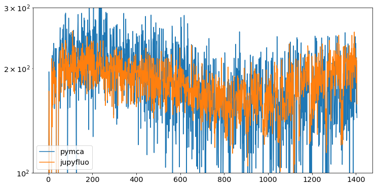

```python
x = data_pymca['column']
y_pymca = data_pymca['S_Kb']
y_jupy = data_jupy['area_S_K']

# Average ratio to scale the two curves
ratio = np.nanmean(y_pymca/y_jupy)

fig = plt.figure(figsize=(12,6))
plt.plot(x, y_pymca, label = 'pymca')
plt.plot(x, y_jupy*ratio, label = 'jupyfluo')
plt.yscale('log')
plt.ylim(1e2,3e2)
plt.legend()
plt.show()
```

#### Area El

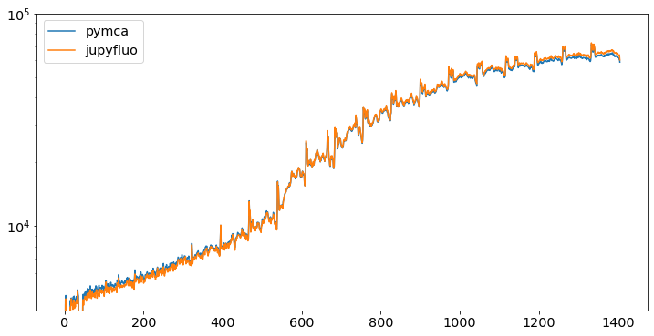

```python
x = data_pymca['column']
y_pymca = data_pymca['Scatter_Peak000']
y_jupy = data_jupy['area_Elastic_El']

# Average ratio to scale the two curves
ratio = np.nanmean(y_pymca/y_jupy)

fig = plt.figure(figsize=(12,6))
plt.plot(x, y_pymca, label = 'pymca')
plt.plot(x, y_jupy*ratio, label = 'jupyfluo')
plt.yscale('log')
plt.ylim(4e3,1e5)
plt.legend()
plt.show()
```

#### Ratio Area Au / Area El

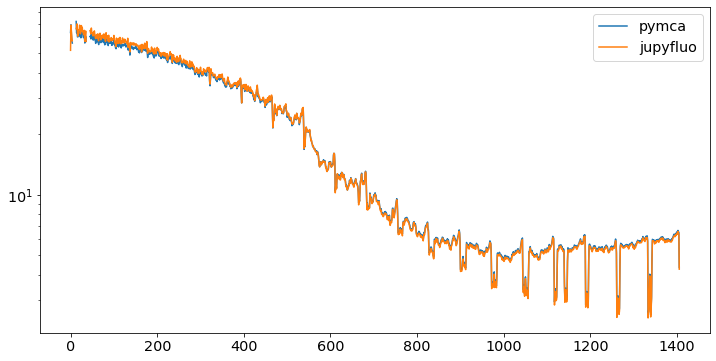

```python
x = data_pymca['column']
y_pymca = data_pymca['Au_L']/data_pymca['Scatter_Peak000']
y_jupy = data_jupy['area_Au_L']/data_jupy['area_Elastic_El']

# Average ratio to scale the two curves
ratio = np.nanmean(y_pymca/y_jupy)

fig = plt.figure(figsize=(12,6))
plt.plot(x, y_pymca, label = 'pymca')
plt.plot(x, y_jupy*ratio, label = 'jupyfluo')
plt.yscale('log')
#plt.ylim(4e3,1e5)
plt.legend()
plt.show()
```

# SIRIUS_Fluo_2021_07_10_0172

## Fit with JupyFluo

### Session ID: 20220208_203103

Fit results for file `SIRIUS_Fluo_2021_07_10_0172.nxs`  
Parameters and results saved in:  
`save/SIRIUS_Fluo_2021_07_10_0172/20220208_203103/`

**Extraction parameters**  
Spectrum interval = [0, 1201]  
Channel interval = [150, 1250]  
SDD elements used = [4]

**Fit parameters**  
List of fitted parameters: ['ct']  
beam energy = 12000; min. strength = 0.01  
**Params for conversion to eVs**  
gain = 9.928; eV0 = -19.6691  
**Params for linear background**  
slope = 0; constant = 1.5411  
Fit the background on the subset [3800 eV, 4100 eV]  
**Params for elastic peaks**  
noise = 0.1353; tail fraction (low energy side) = 0.05  
tail width (low energy side) = 1.3054; shelf fraction = 1  
**Params for Compton peaks**  
broadening factor = 1; tail fraction (low energy side) = 0.2647; tail fraction (high energy side) = 0  
tail width (low energy side) = 3; tail width (high energy side) = 0

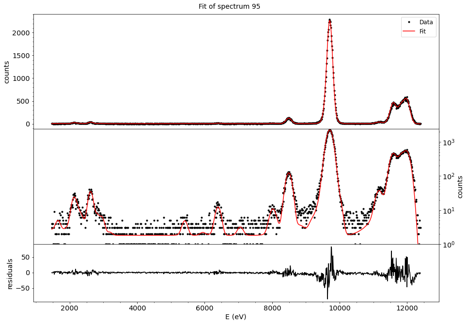

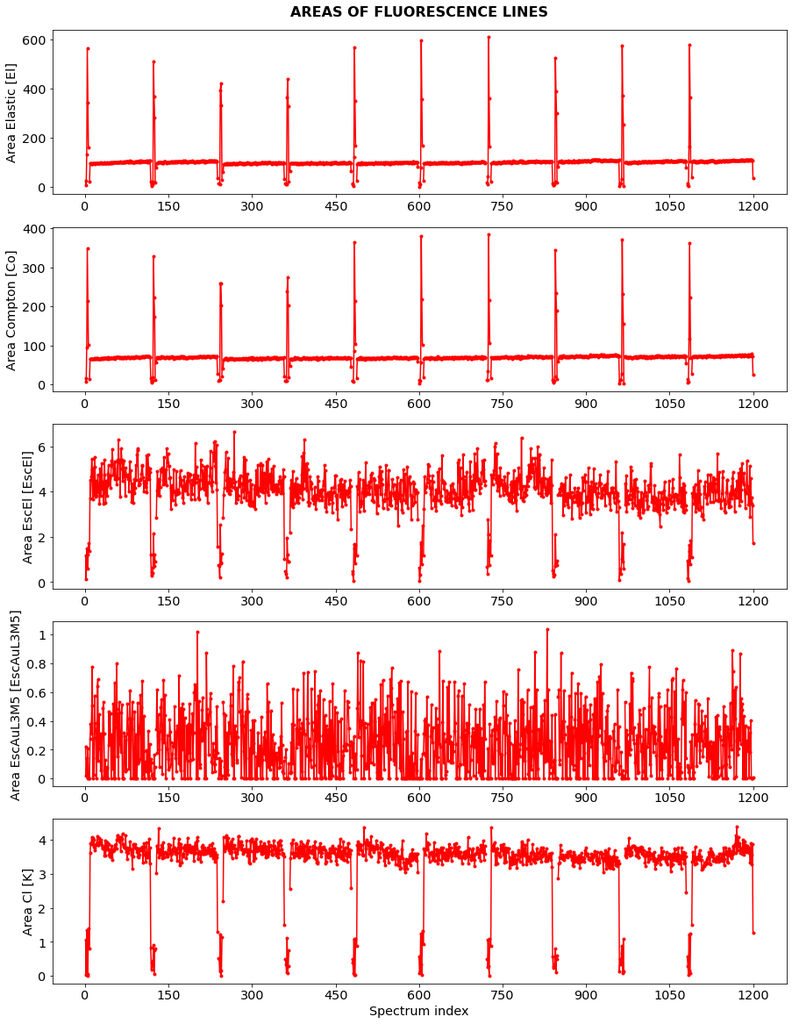

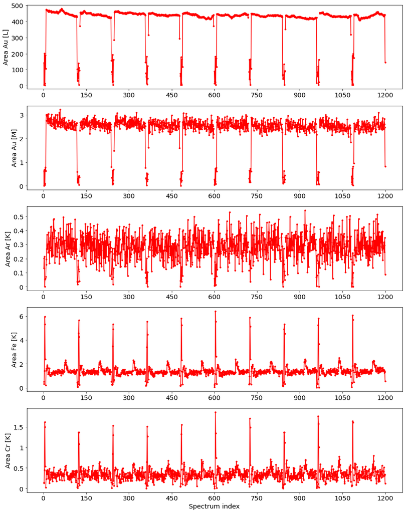

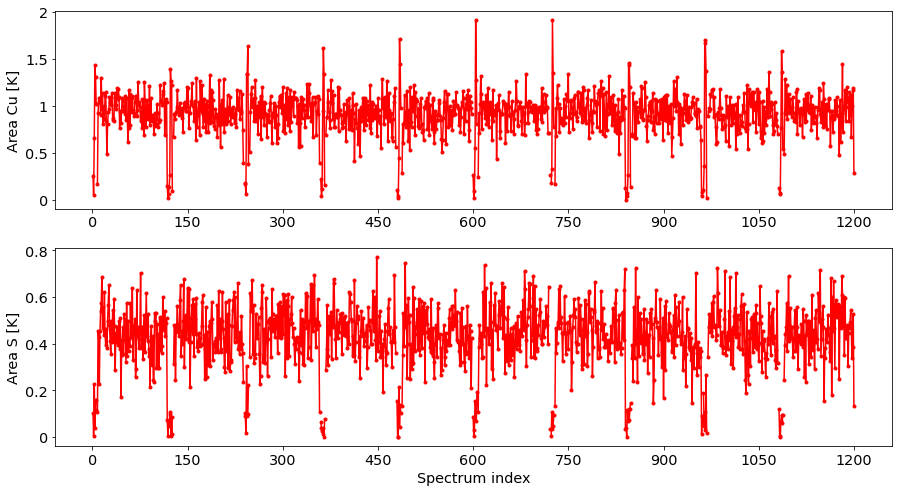

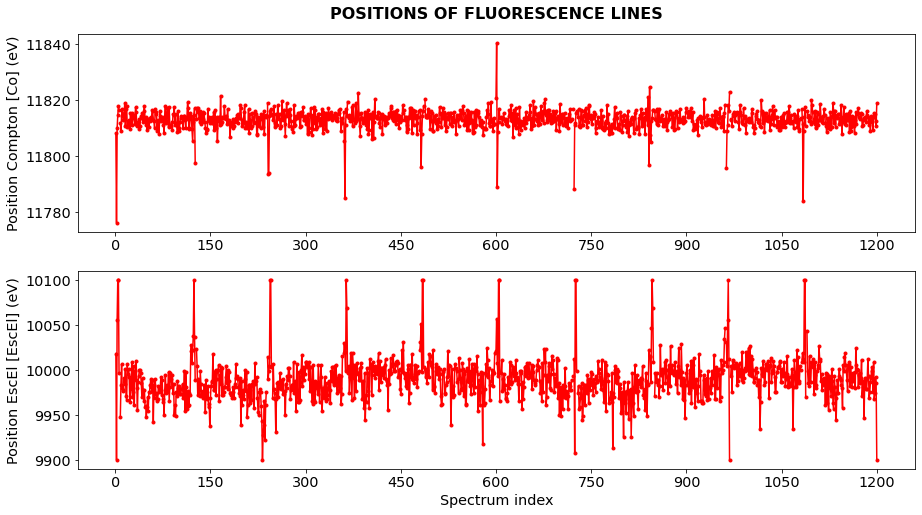

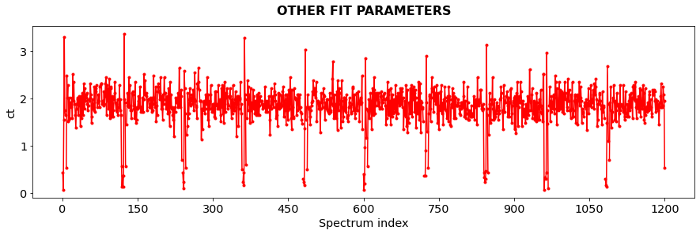

```python
fit_index=95
path_to_result_folder='save/SIRIUS_Fluo_2021_07_10_0172/20220208_203103/'
expt.plot_all_fit_results(fit_index, path_to_result_folder)
```

## Comparison with PyMca

### Curves

```python
file_curve_pymca = '../172/Results_batch/FIT/SIRIUS_Fluo_2021_07_10_0172.nxs_FITDIR/SIRIUS_Fluo_2021_07_10_0172.nxs_1.0000.0095.fit'
with open(file_curve_pymca) as a_file:
    for line in a_file:
        if 'energy = [' in line:
            energy_pymca = [float(x)*1000. for x in line.split('energy = ')[1][2:-3].split(' ')]
        if 'ydata = [' in line:
            ydata_pymca = [float(x) for x in line.split('ydata = ')[1][2:-3].split(' ')]
        if 'yfit = [' in line:
            yfit_pymca = [float(x) for x in line.split('yfit = ')[1][2:-3].split(' ')]


file_curve_jupy = 'save/SIRIUS_Fluo_2021_07_10_0172/20220208_203103/fit_curves/spectrum_95.csv'
curve_jupy = np.genfromtxt(file_curve_jupy, delimiter =';', names = True)

energy_jupy = curve_jupy['eVs']
ydata_jupy = curve_jupy['data']
yfit_jupy = curve_jupy['fit']
```

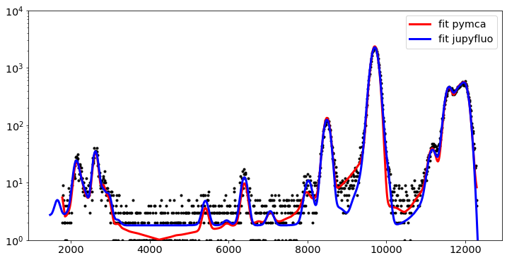

```python
fig = plt.figure(figsize=(12,6))
plt.plot(energy_pymca, ydata_pymca, 'k.')
plt.plot(energy_pymca, yfit_pymca, 'r-', lw = 3, label = 'fit pymca')
plt.plot(energy_jupy, yfit_jupy, 'b-', lw = 3, label = 'fit jupyfluo')

#plt.plot(x, y_jupy*ratio, label = 'jupyfluo')
plt.yscale('log')
plt.ylim(1,1e4)
plt.legend()
plt.show()
```

### Fit results

```python
data_pymca = np.genfromtxt('../172/Results_batch/IMAGES/SIRIUS_Fluo_2021_07_10_0172.csv',
                     delimiter =';', names = True)
print('header pymca:\n',data_pymca.dtype.names)
data_jupy = np.genfromtxt('save/SIRIUS_Fluo_2021_07_10_0172/20220208_203103/fit_results.csv',
                           delimiter =';', names = True)
print('')
print('header jupyfluo:\n',data_jupy.dtype.names)
```

```
header pymca:
 ('row', 'column', 'S_Ka', 'S_Kb', 'Cl_Ka', 'Cl_Kb', 'Ar_K', 'Cr_K', 'Fe_K', 'Ni_K', 'Cu_K', 'Au_L', 'Au_M', 'Scatter_Peak000', 'Scatter_Compton000', 'sS_Ka', 'sS_Kb', 'sCl_Ka', 'sCl_Kb', 'sAr_K', 'sCr_K', 'sFe_K', 'sNi_K', 'sCu_K', 'sAu_L', 'sAu_M', 'sScatter_Peak000', 'sScatter_Compton000', 'chisq…

header jupyfluo:
 ('ys', 'zs', 'xs', 'surfacepressure', 'areapermolecule', 'fluo00', 'fluo01', 'fluo02', 'fluo03', 'fluoicr04', 'fluoocr04', 'qxy', 'm4pitch', 'integration_time', 'sensorsRelTimestamps', 'sensorsTimestamps', 'spectrum_index', 'area_Elastic_El', 'stderr_area_Elastic_El', 'area_Compton_Co', 'stderr_are…
```

#### Area Au

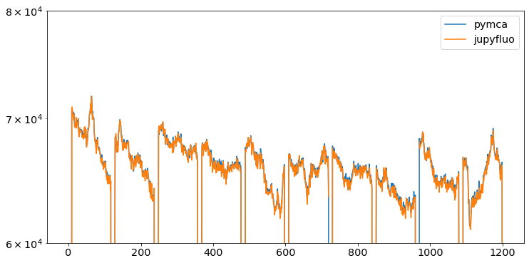

```python
x = data_pymca['column']
y_pymca = data_pymca['Au_L']
y_jupy = data_jupy['area_Au_L']

# Average ratio to scale the two curves
ratio = np.nanmean(y_pymca/y_jupy)

fig = plt.figure(figsize=(12,6))
plt.plot(x, y_pymca, label = 'pymca')
plt.plot(x, y_jupy*ratio, label = 'jupyfluo')
plt.yscale('log')
plt.ylim(6e4,8e4)
plt.legend()
plt.show()
```

#### Area Cl

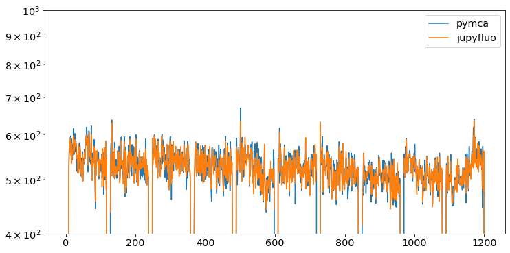

```python
x = data_pymca['column']
y_pymca = data_pymca['Cl_Ka']
y_jupy = data_jupy['area_Cl_K']

# Average ratio to scale the two curves
ratio = 145.

fig = plt.figure(figsize=(12,6))
plt.plot(x, y_pymca, label = 'pymca')
plt.plot(x, y_jupy*ratio, label = 'jupyfluo')
plt.yscale('log')
plt.ylim(4e2,1e3)
plt.legend()
plt.show()
```

#### Area El

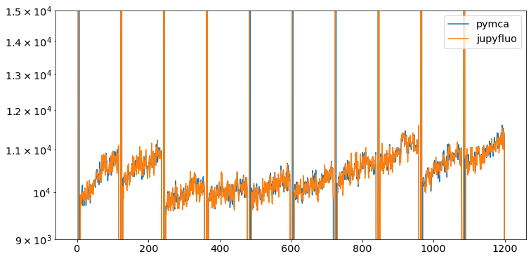

```python
x = data_pymca['column']
y_pymca = data_pymca['Scatter_Peak000']
y_jupy = data_jupy['area_Elastic_El']

# Average ratio to scale the two curves
ratio = np.nanmean(y_pymca/y_jupy)

fig = plt.figure(figsize=(12,6))
plt.plot(x, y_pymca, label = 'pymca')
plt.plot(x, y_jupy*ratio, label = 'jupyfluo')
plt.yscale('log')
plt.ylim(9e3,1.5e4)
plt.legend()
plt.show()
```

#### Ratio Area Au / Area El

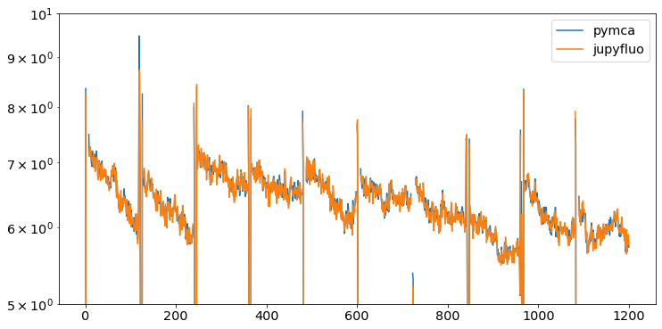

```python
x = data_pymca['column']
y_pymca = data_pymca['Au_L']/data_pymca['Scatter_Peak000']
y_jupy = data_jupy['area_Au_L']/data_jupy['area_Elastic_El']

# Average ratio to scale the two curves
ratio = np.nanmean(y_pymca/y_jupy)

fig = plt.figure(figsize=(12,6))
plt.plot(x, y_pymca, label = 'pymca')
plt.plot(x, y_jupy*ratio, label = 'jupyfluo')
plt.yscale('log')
plt.ylim(5,10)
plt.legend()
plt.show()
```

### Comparison with ROI (from PyMca)

```python
data_pymca = np.genfromtxt('../172/Results_ROI/IMAGES/SIRIUS_Fluo_2021_07_10_0172_0100eVROI.csv',
                     delimiter =';', names = True)
print('header pymca:\n',data_pymca.dtype.names)
data_jupy = np.genfromtxt('save/SIRIUS_Fluo_2021_07_10_0172/20220208_203103/fit_results.csv',
                           delimiter =';', names = True)
print('')
print('header jupyfluo:\n',data_jupy.dtype.names)
```

```
header pymca:
 ('row', 'column', 'S_Ka_KL3a', 'S_Kb_KM3b', 'Cl_Ka_KL3a', 'Cl_Kb_KM3b', 'Ar_K_KL3', 'Ar_K_KM3', 'Cr_K_KL3', 'Cr_K_KM3', 'Fe_K_KL3', 'Fe_K_KM3', 'Ni_K_KL3', 'Ni_K_KM3', 'Cu_K_KL3', 'Cu_K_KM3', 'Au_L_L3M5', 'Au_L_L3N5', 'Au_L_L3M1', 'Au_L_L3O45', 'Au_M_M5N7', 'Au_M_M4N2', 'Au_M_M3N5', 'Au_M_M3N1', 'A…

header jupyfluo:
 ('ys', 'zs', 'xs', 'surfacepressure', 'areapermolecule', 'fluo00', 'fluo01', 'fluo02', 'fluo03', 'fluoicr04', 'fluoocr04', 'qxy', 'm4pitch', 'integration_time', 'sensorsRelTimestamps', 'sensorsTimestamps', 'spectrum_index', 'area_Elastic_El', 'stderr_area_Elastic_El', 'area_Compton_Co', 'stderr_are…
```

#### Area Au

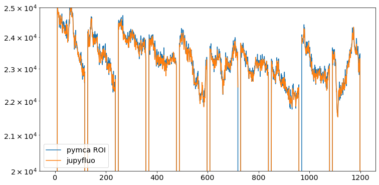

```python
x = data_pymca['column']
y_pymca = data_pymca['Au_L_L3M5']
y_jupy = data_jupy['area_Au_L']

# Average ratio to scale the two curves
ratio = np.nanmean(y_pymca/y_jupy)

fig = plt.figure(figsize=(12,6))
plt.plot(x, y_pymca, label = 'pymca ROI')
plt.plot(x, y_jupy*ratio, label = 'jupyfluo')
plt.yscale('log')
plt.ylim(2e4,2.5e4)
plt.legend()
plt.show()
```

# SIRIUS_Fluo_2021_04_16_0161

## Fit with JupyFluo

### Session ID: 20220215_115348

Fit results for file `SIRIUS_Fluo_2021_04_16_0161.nxs`  
Parameters and results saved in:  
`save/SIRIUS_Fluo_2021_04_16_0161/20220215_115348/`

**Extraction parameters**  
Spectrum interval = [0, 114]  
Channel interval = [180, 830]  
SDD elements used = [4]

**Fit parameters**  
List of fitted parameters: ['ct']  
beam energy = 8000; min. strength = 0.01  
**Params for conversion to eVs**  
gain = 9.933; eV0 = -9.443  
**Params for linear background**  
slope = 0; constant = 9.6843  
Fit the background on the subset [4000 eV, 4600 eV]  
**Params for elastic peaks**  
noise = 0.1084; tail fraction (low energy side) = 0  
tail width (low energy side) = 0; shelf fraction = 1.8687  
**Params for Compton peaks**  
broadening factor = 1.437; tail fraction (low energy side) = 0.1342; tail fraction (high energy side) = 0  
tail width (low energy side) = 3.1664; tail width (high energy side) = 0

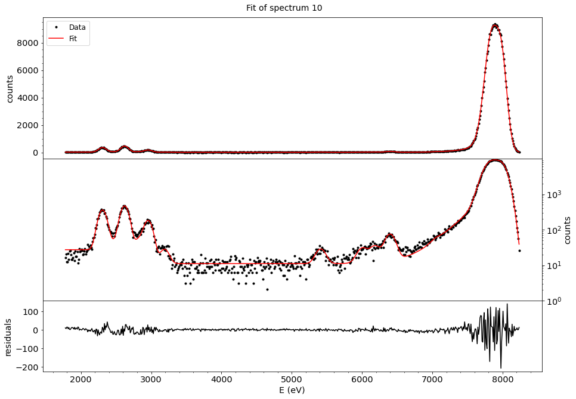

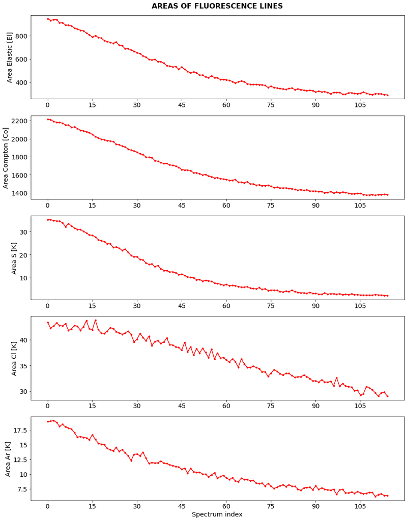

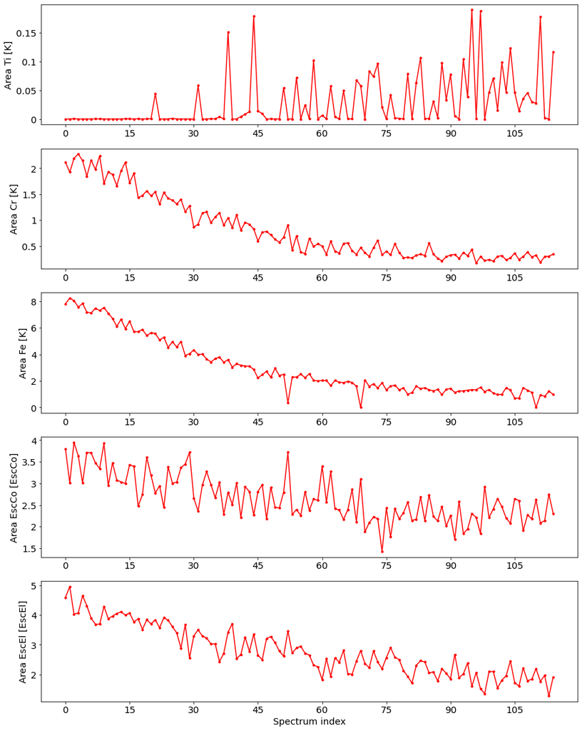

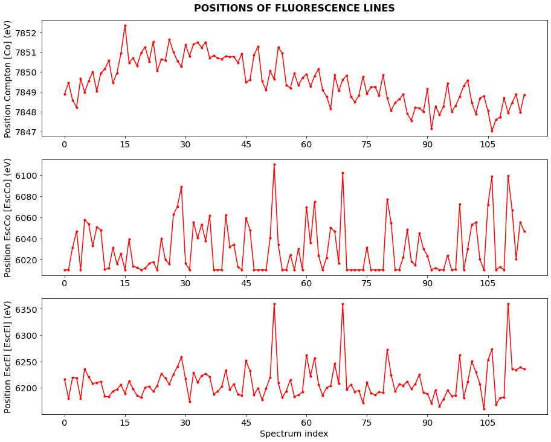

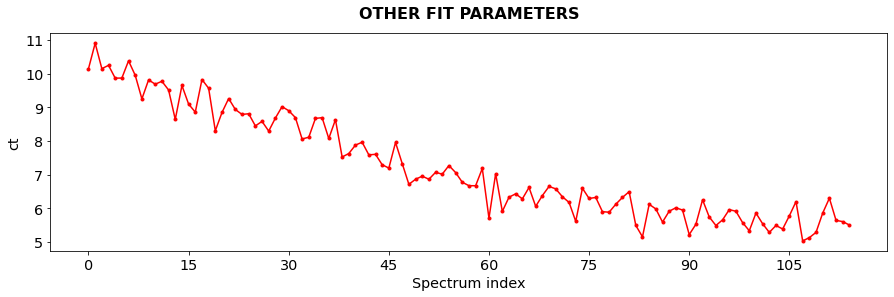

```python
fit_index=10
path_to_result_folder='save/SIRIUS_Fluo_2021_04_16_0161/20220215_115348/'
expt.plot_all_fit_results(fit_index, path_to_result_folder)
```

## Comparison with PyMca

### Curves

```python
file_curve_pymca = '../161/Results_batch/FIT/SIRIUS_Fluo_2021_04_16_0161.nxs_FITDIR/SIRIUS_Fluo_2021_04_16_0161.nxs_1.0000.0010.fit'
with open(file_curve_pymca) as a_file:
    for line in a_file:
        if 'energy = [' in line:
            energy_pymca = [float(x)*1000. for x in line.split('energy = ')[1][2:-3].split(' ')]
        if 'ydata = [' in line:
            ydata_pymca = [float(x) for x in line.split('ydata = ')[1][2:-3].split(' ')]
        if 'yfit = [' in line:
            yfit_pymca = [float(x) for x in line.split('yfit = ')[1][2:-3].split(' ')]


file_curve_jupy = 'save/SIRIUS_Fluo_2021_04_16_0161/20220215_115348/fit_curves/spectrum_10.csv'
curve_jupy = np.genfromtxt(file_curve_jupy, delimiter =';', names = True)

energy_jupy = curve_jupy['eVs']
ydata_jupy = curve_jupy['data']
yfit_jupy = curve_jupy['fit']
```

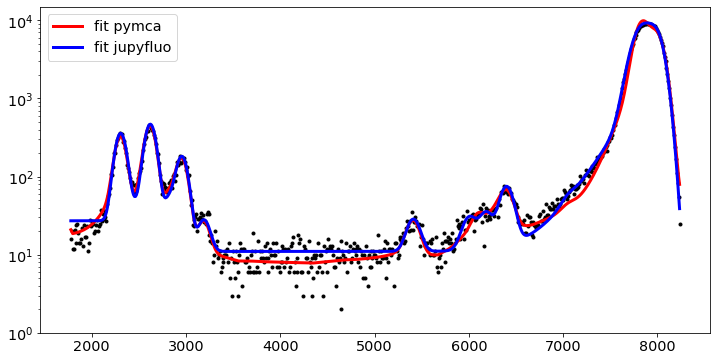

```python
fig = plt.figure(figsize=(12,6))
plt.plot(energy_pymca, ydata_pymca, 'k.')
plt.plot(energy_pymca, yfit_pymca, 'r-', lw = 3, label = 'fit pymca')
plt.plot(energy_jupy, yfit_jupy, 'b-', lw = 3, label = 'fit jupyfluo')

#plt.plot(x, y_jupy*ratio, label = 'jupyfluo')
plt.yscale('log')
plt.ylim(1,1.5e4)
plt.legend()
plt.show()
```

### Fit results

```python
data_pymca = np.genfromtxt('../161/Results_batch/IMAGES/SIRIUS_Fluo_2021_04_16_0161.csv',
                     delimiter =';', names = True)
print('header pymca:\n',data_pymca.dtype.names)
data_jupy = np.genfromtxt('save/SIRIUS_Fluo_2021_04_16_0161/20220215_115348/fit_results.csv',
                           delimiter =';', names = True)
print('')
print('header jupyfluo:\n',data_jupy.dtype.names)
```

```
header pymca:
 ('row', 'column', 'S_Ka', 'S_Kb', 'Cl_K', 'Ar_K', 'Ti_K', 'Cr_K', 'Fe_K', 'Scatter_Peak000', 'Scatter_Compton000', 'sS_Ka', 'sS_Kb', 'sCl_K', 'sAr_K', 'sTi_K', 'sCr_K', 'sFe_K', 'sScatter_Peak000', 'sScatter_Compton000', 'chisq')

header jupyfluo:
 ('ys', 'zs', 'xs', 'surfacepressure', 'areapermolecule', 'fluo00', 'fluo01', 'fluo02', 'fluo03', 'fluoicr04', 'fluoocr04', 'qxy', 'm4pitch', 'integration_time', 'sensorsRelTimestamps', 'sensorsTimestamps', 'spectrum_index', 'area_Elastic_El', 'stderr_area_Elastic_El', 'area_Compton_Co', 'stderr_are…
```

#### Area S

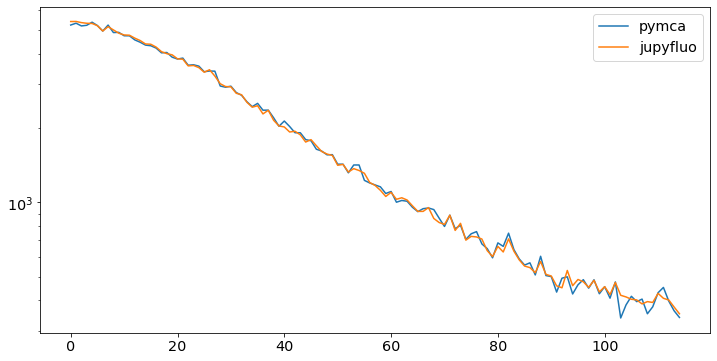

```python
x = data_pymca['column']
y_pymca = data_pymca['S_Ka']
y_jupy = data_jupy['area_S_K']

# Average ratio to scale the two curves
ratio = np.nanmean(y_pymca/y_jupy)

fig = plt.figure(figsize=(12,6))
plt.plot(x, y_pymca, label = 'pymca')
plt.plot(x, y_jupy*ratio, label = 'jupyfluo')
plt.yscale('log')
plt.legend()
plt.show()
```